# MATH-256 - Lab #2 - Data Exploration

This lab is aimed at provide you examples and practice using some `R` commands that are used to generate tables/graphs that are essential to data exploration.

It will require you to install and load the `ggplot2` graphing package.

```r
#install.packages("ggplot2")
library(ggplot2)
```

You will also need to submit your answers using the R Markdown template [linked here](https://remiller1450.github.io/m256f20/Lab_2_answer_template.Rmd). In order for this to work you’ll need to install the `rmarkdown` package.

```r
#install.packages("rmarkdown")
library(rmarkdown)
```

Please fill in this template with your code and typed answers and use the “Knit” button to make a nifty document that contains your R code, it’s output, and your written responses.

$~$

# College Scorecard Data

The College Scorecard is a government run database that stores institutional level data on all accredited colleges and universities in the United States. A new version of the data is published yearly, and contains over 400 variables. This lab will use a simplified dataset from the 2019-2020 academic year.

## Data Dictionary

The [College19 Dataset](https://remiller1450.github.io/data/Colleges19.csv) is a reduced version of the 2019-2020 College Scorecard data that includes fewer variables and is filtered to include only primarily undergraduate institutions with at least 400 enrolled students. It contains the following variables:

- **Name** - Name of the institution
- **City** - City where the institution is located
- **State** - State where the institution is located
- **Enrollment** - Number of full-time enrolled students
- **Private** - Binary indicator distinguishing public and private institutions
- **Region** - Geographic region
- **Adm_Rate** - Admissions rate, the proportion of applications who are admitted
- **ACT_median** - Median composite ACT score of enrolled students
- **ACT_Q1** - 25th percentile composite ACT score of enrolled students
- **ACT_Q3** - 75th percentile composite ACT score of enrolled students
- **Cost** - Average yearly cost of attendance
- **Net_Tuition** - Average tuition cost after discounts (scholarships, grants, etc.)
- **Avg_Fac_Salary** - Average faculty salary
- **PercentFemale** - Proportion of enrolled students who are female
- **PercentWhite** - Proportion of enrolled students who identify as White
- **PercentBlack** - Proportion of enrolled students who identify as Black
- **PercentHispanic** - Proportion of enrolled students who identify as Hispanic
- **PercentAsian** - Proportion of enrolled students who identify as Asian
- **FourYearComp_Males** - Proportion of male students who go on to earn a degree within four years of their initial enrollment
- **FourYearComp_Females** - Proportion of male students who go on to earn a degree within four years of their initial enrollment
- **Debt_median** - Median student debt upon leaving the institution
- **Salary10yr_median** - Median salary 10 years after graduating the institution

$~$

## First Steps

The first step in any data analysis is getting a high-level understanding of the data. This means describing the cases and how many there are, as well as looking over the variables and being aware of how they’re recorded.

Some helpful commands are shown below:

```r
## Begin by reading in the data
colleges19 <- read.csv("https://remiller1450.github.io/data/Colleges2019.csv")

## Print the dimensions
dim(colleges19)

## Print the "structure" of the data.frame
str(colleges19)
```

**Question #1**: Copy the *two commands* given above that read-in the data and print its dimension into the Question #1 code block (ie: the grey area between the ```{r} and ``` under the Question #1 header). Then, in space beneath the code block intended for written responses, describe how many cases there are and what they represent.

$~$

## Univariate Exploration

After getting a preliminary sense of what the data contain, the next step is to explore the distributions of the variables of interest. This step is important in identifying possible outliers, variables with unusual distributions, or missing data.

`R` has a built-in summary function that is quite convenient (at least for numeric variables):

```r
summary(colleges19)
```

To generate visualizations you should browse the References/Examples that I’ve provided in the last sections of this document. The questions below will help you get some practice with this.

**Question #2**: Choose one *categorical* variable that interests you and create an appropriate visualization of it (again, put the code that creates the graph into the Question #2 code block). Then, in space beneath the code block intended for written responses, briefly describe why you chose this variable.

**Question #3**: Choose one *numeric* variable that interests you and create an appropriate visualization of it. Put your code in the proper block for this question. Then, in space beneath the code block, briefly describe why you chose this variable.

Please note, before doing *any* statistical analysis my advice is to always graph the variables that are involved. This helps prevent you from making mistakes (remember the correlation examples we covered in class).

$~$

## Finding Associations

As we’ve discussed, most interesting questions involve relating two or more variables. To review, here are some general tips for exploring relationships between pairs of variables:

- Use a stacked and conditional bar chart to explore relationships involving *two categorical* variables
- Use box plots to explore relationships involving *one categorical* and *one numeric* variable
- Use a scatterplot to explore relationships involving *two numeric* variables

**Question #4**: Identify two variables you think might share an interesting relationship and create an appropriate visualization. Put your code in the proper block. Then, in space beneath the code block, briefly describe what you see in the graph you created.

$~$

## Multivariate Exploration

After identifying an association between two variables, it is prudent to explore whether there might be one or more *confounding variables* influencing the patterns we observed. The exception is when we’re dealing with a well-designed randomized experiment.

**Question #5**: Identify a third variable that you think might be related to the two variables you explored in Question #4. Create a new graph that incorporates all three of these variables. Put your code in the proper block. Then, in space beneath the code block, briefly describe what you see in the graph you created.

$~$

## Reporting the Association

After visually identifying an association, the final step (at least for this point in the course) is to report the association using an appropriate summary measure. Here are some general tips for doing this:

- When comparing *two categorical* variables, report an appropriate set of conditional proportions
- When comparing *two numeric* variables, report the correlation coefficient
- When comparing *one numeric* and *one categorical* variable, report an appropriate set of means/medians/standard deviations
- **Note**: If a confounding variable exists, you should stratify by it and report your summary measures separately for each stratum

**Question #6**: Using the original variables you chose back in Question #4, provide an appropriate numeric summary of their relationship. Put the code you used to find your summary measures into the proper block. If you’re using a categorical variable with many categories, you are welcome to restrict your comparison to small number of them (ie: Report on OH vs KY rather than trying to report differences across all of different US states)

$~$

# References and examples

The sections that follow provide easy to follow examples on how to obtain some frequently sought after graphs or summary information.

## Visualization

```r
## Read in the "Tips" data to use in examples
example_data <- read.csv("https://remiller1450.github.io/data/Tips.csv")
```

### Scatterplot (basic)

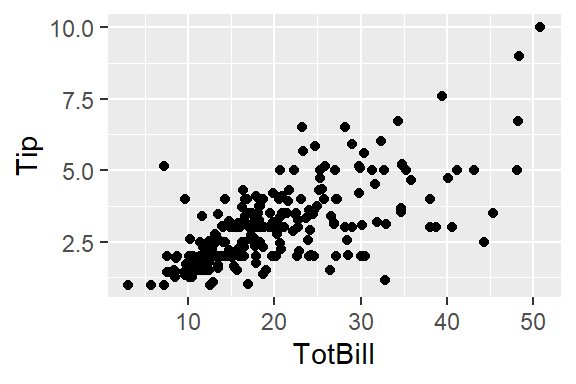

```r
ggplot(example_data, aes(x = TotBill, y = Tip)) + geom_point()
```

### Scatterplot (color by group)

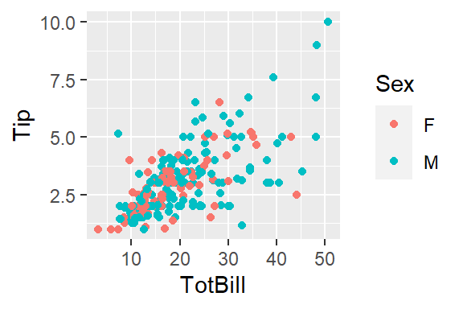

```r
ggplot(example_data, aes(x = TotBill, y = Tip, color = Sex)) + geom_point()
```

### Scatterplot (color by numeric)

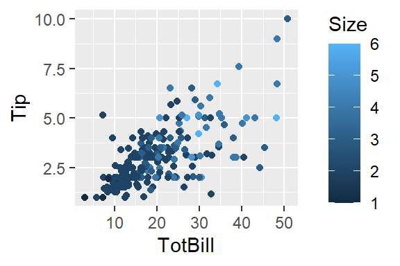

```r
ggplot(example_data, aes(x = TotBill, y = Tip, color = Size)) + geom_point()
```

### Boxplot (simple)

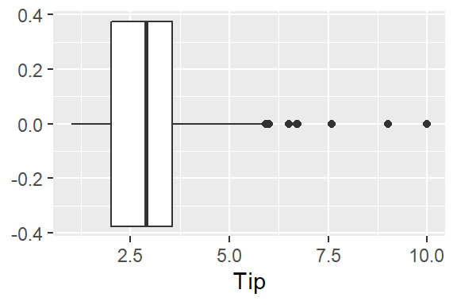

```r
ggplot(example_data, aes(x = Tip)) + geom_boxplot()
```

### Boxplot (by group)

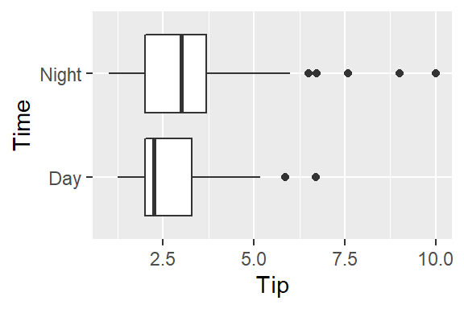

```r
ggplot(example_data, aes(x = Tip, y = Time)) + geom_boxplot()
```

### Boxplot (by group, stratified)

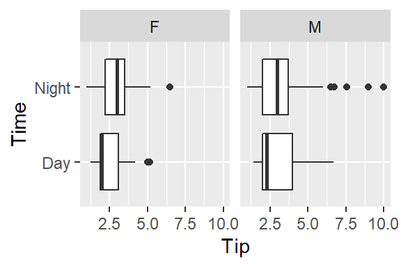

```r
ggplot(example_data, aes(x = Tip, y = Time)) + geom_boxplot() + facet_wrap(~Sex)
```

### Histogram

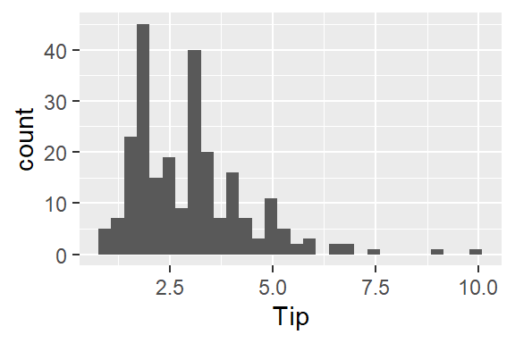

```r
ggplot(example_data, aes(x = Tip)) + geom_histogram()
```

### Barchart (simple)

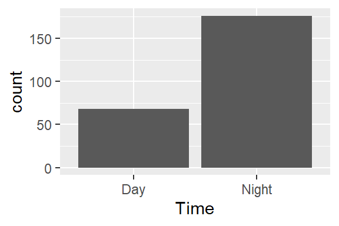

```r
ggplot(example_data, aes(x = Time)) + geom_bar()
```

### Barchart (stacked)

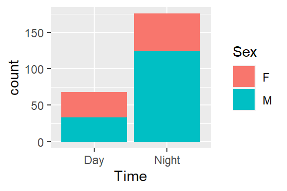

```r
ggplot(example_data, aes(x = Time, fill = Sex)) + geom_bar()
```

### Barchart (conditional)

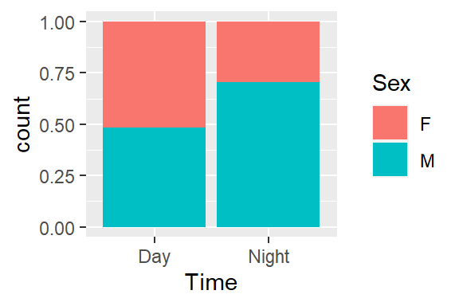

```r
ggplot(example_data, aes(x = Time, fill = Sex)) + geom_bar(position = "fill")
```

### Barchart (conditional, stratified)

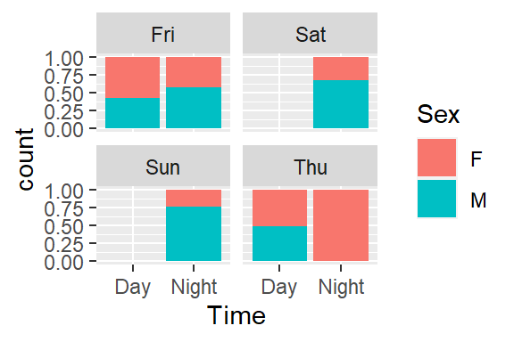

```r
ggplot(example_data, aes(x = Time, fill = Sex)) + geom_bar(position = "fill") + facet_wrap(~Day)
```

## Summarization

```r
## Read in the "Tips" data to use in examples
example_data <- read.csv("https://remiller1450.github.io/data/Tips.csv")
```

### Default Numeric Summary

```r
summary(example_data)
```

```
##     TotBill           Tip             Sex               Smoker
##  Min.   : 3.07   Min.   : 1.000   Length:244         Length:244
##  1st Qu.:13.35   1st Qu.: 2.000   Class :character   Class :character
##  Median :17.80   Median : 2.900   Mode  :character   Mode  :character
##  Mean   :19.79   Mean   : 2.998
##  3rd Qu.:24.13   3rd Qu.: 3.562
##  Max.   :50.81   Max.   :10.000
##      Day                Time                Size
##  Length:244         Length:244         Min.   :1.00
##  Class :character   Class :character   1st Qu.:2.00
##  Mode  :character   Mode  :character   Median :2.00
##                                        Mean   :2.57
##                                        3rd Qu.:3.00
##                                        Max.   :6.00
```

### After Subsetting

```r
summary(example_data[example_data$Sex == "M",])  # Only male customers
```

```
##     TotBill           Tip            Sex               Smoker
##  Min.   : 7.25   Min.   : 1.00   Length:157         Length:157
##  1st Qu.:14.00   1st Qu.: 2.00   Class :character   Class :character
##  Median :18.35   Median : 3.00   Mode  :character   Mode  :character
##  Mean   :20.74   Mean   : 3.09
##  3rd Qu.:24.71   3rd Qu.: 3.76
##  Max.   :50.81   Max.   :10.00
##      Day                Time                Size
##  Length:157         Length:157         Min.   :1.000
##  Class :character   Class :character   1st Qu.:2.000
##  Mode  :character   Mode  :character   Median :2.000
##                                        Mean   :2.631
##                                        3rd Qu.:3.000
##                                        Max.   :6.000
```

```r
summary(example_data[example_data$Tip > 5,])  # Only tips above $5
```

```
##     TotBill           Tip             Sex               Smoker
##  Min.   : 7.25   Min.   : 5.070   Length:18          Length:18
##  1st Qu.:26.46   1st Qu.: 5.178   Class :character   Class :character
##  Median :30.16   Median : 5.885   Mode  :character   Mode  :character
##  Mean   :31.94   Mean   : 6.273
##  3rd Qu.:34.83   3rd Qu.: 6.650
##  Max.   :50.81   Max.   :10.000
##      Day                Time                Size
##  Length:18          Length:18          Min.   :2.000
##  Class :character   Class :character   1st Qu.:3.000
##  Mode  :character   Mode  :character   Median :4.000
##                                        Mean   :3.667
##                                        3rd Qu.:4.000
##                                        Max.   :6.000
```

### Standard deviation

```r
sd(example_data$Tip)
```

```
## [1] 1.383638
```

### Percentiles

```r
quantile(example_data$Tip, .9)
```

```
## 90%
##   5
```

### Tables (one-way)

```r
table(example_data$Day)
```

```
##
## Fri Sat Sun Thu
##  19  87  76  62
```

### Tables (two-way)

```r
table(example_data$Sex, example_data$Day)
```

```
##
##     Fri Sat Sun Thu
##   F   9  28  18  32
##   M  10  59  58  30
```

### Tables (row props)

```r
my_table <- table(example_data$Sex, example_data$Day)
prop.table(my_table, margin = 1)
```

```
##
##            Fri        Sat        Sun        Thu
##   F 0.10344828 0.32183908 0.20689655 0.36781609
##   M 0.06369427 0.37579618 0.36942675 0.19108280
```

### Tables (column props)

```r
my_table <- table(example_data$Sex, example_data$Day)
prop.table(my_table, margin = 2)
```

```
##
##           Fri       Sat       Sun       Thu
##   F 0.4736842 0.3218391 0.2368421 0.5161290
##   M 0.5263158 0.6781609 0.7631579 0.4838710
```

### Tables (stratified/three-way)

```r
table(example_data$Sex, example_data$Day, example_data$Time)
```

```
## , ,  = Day
##
##
##     Fri Sat Sun Thu
##   F   4   0   0  31
##   M   3   0   0  30
##
## , ,  = Night
##
##
##     Fri Sat Sun Thu
##   F   5  28  18   1
##   M   7  59  58   0
```

### Correlation

```r
cor(example_data$TotBill, example_data$Tip)
```

```
## [1] 0.6757341
```

### Correlation (stratified)

```r
## First do the stratification
smokers <- example_data[example_data$Smoker == "Yes",]
non_smokers <- example_data[example_data$Smoker == "No",]

## Then calculate the correlations
cor(smokers$TotBill, smokers$Tip)
```

```
## [1] 0.4882179
```

```r
cor(non_smokers$TotBill, non_smokers$Tip)
```

```
## [1] 0.8221826
```